# Basics and CART

This notebook contains code from 1-basics-cart.R and the corresponding output.

## Some data exploration

After all packages and data have been loaded and set up (see 1-basics-cart.R), we might want to explore the training set using graphs. Here is a nice plot using `ggpairs` from the `GGally` package.

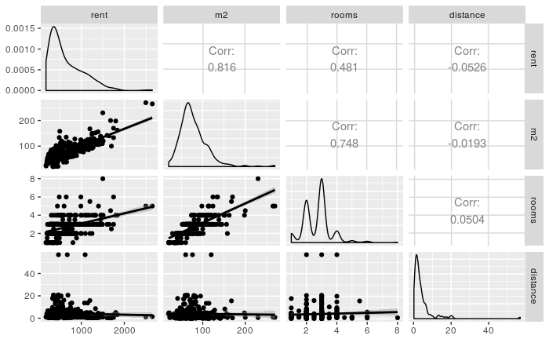

```r
ggpairs(bremen_train_c[,c(2:4,10)], lower = list(continuous = "smooth"))
```

## Grow and prune tree

Our task is to predict rent using $m^2$, rooms, location, city and distance to city center as features. In order to grow a regression tree, `rpart` is used here, which follows the CART idea.

```r
set.seed(733)
f_tree <- rpart(rent ~ m2 + rooms + lon + lat + city + distance, data = bremen_train_c, cp = 0.005)
printcp(f_tree)
```

```
Regression tree:
rpart(formula = rent ~ m2 + rooms + lon + lat + city + distance,
    data = bremen_train_c, cp = 0.005)

Variables actually used in tree construction:
[1] distance lat      lon      m2       rooms

Root node error: 65198484/422 = 154499

n= 422

          CP nsplit rel error  xerror     xstd
1  0.5389484      0   1.00000 1.00334 0.100360
2  0.1010264      1   0.46105 0.50262 0.056194
3  0.0726454      2   0.36003 0.39893 0.054758
4  0.0565453      3   0.28738 0.37365 0.051279
5  0.0379306      4   0.23083 0.28500 0.038874
6  0.0204183      5   0.19290 0.22549 0.028357
7  0.0111684      6   0.17249 0.21880 0.028187
8  0.0083166      7   0.16132 0.19443 0.027651
9  0.0072267      8   0.15300 0.19288 0.027221
10 0.0064449      9   0.14577 0.18897 0.027118
11 0.0064114     10   0.13933 0.18458 0.026831
12 0.0060266     11   0.13292 0.18010 0.026742
13 0.0055061     12   0.12689 0.17586 0.026709
14 0.0050520     13   0.12139 0.16732 0.025883
15 0.0050000     14   0.11633 0.16477 0.025921
```

Given the grown tree, `printcp` and `plotcp` help us to determine the best subtree, whereas `Root node error` times `xerror` gives us the estimated test error for each subtree based on cross-validation.

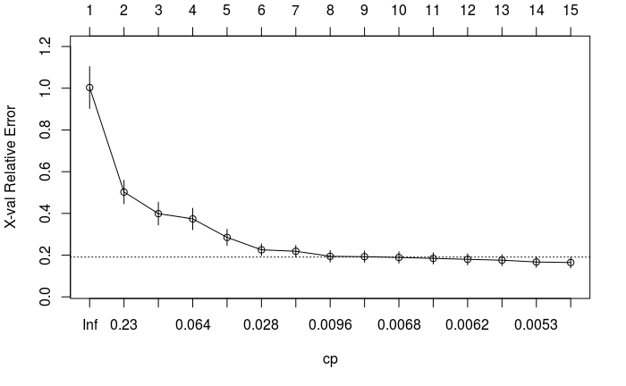

```r
plotcp(f_tree)
```

We can get the best subtree with the `prune` function, here using the one standard error rule.

```r
minx <- which.min(f_tree$cptable[,"xerror"])
minxse <- f_tree$cptable[minx,"xerror"] + f_tree$cptable[minx,"xstd"]
minse <- which.min(abs(f_tree$cptable[,"xerror"] - minxse))
mincp <- f_tree$cptable[minse,"CP"]
p_tree <- prune(f_tree, cp = mincp)
```

## Plots

An advantage of trees is that they can be easily interpreted by a simple plot. The `party` package produces nice tree plots.

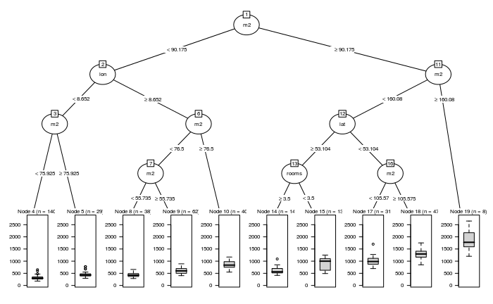

```r
prty_tree <- as.party(p_tree)
plot(prty_tree, gp = gpar(fontsize = 6))
```

If we are interested in the prediction surface of the tree, partial dependence plots using e.g. the `pdp` package can be useful.

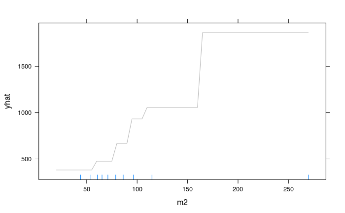

```r
pdp1 <- partial(p_tree, pred.var = "m2")
plotPartial(pdp1, rug = T, train = bremen_train, alpha = 0.3)
```

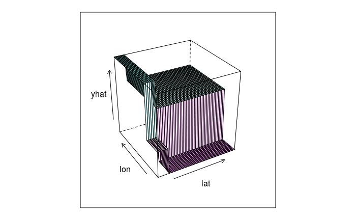

```r
pdp2 <- partial(p_tree, pred.var = c("lat", "lon"))
plotPartial(pdp2, levelplot = F, drape = T, colorkey = F, screen = list(z = 30, x = -60))
```

## Prediction

Finally, we can use the pruned tree in order to predict the outcome in the holdout (test) set. Then, `postResample` produces basic performance measures.

```r
y_tree <- predict(p_tree, newdata = bremen_test)
postResample(pred = y_tree, obs = bremen_test$rent)
```

```
     RMSE  Rsquared
171.99402   0.83339
```